# Independent Sample T-Tests

Homework Quiz

Author

Nathan Lunceford

# It’s a Date!

## Introduction

Dating Behavior was studied in a speed dating experiment where random matching was generated and created randomization in the number of potential dates. In a survey to each participant, one question was asked about how important attraction is when they date. The attraction value is on a scale from 0 (not important at all) to 100 (very important).

The researchers want to determine if males report to value attractiveness more than females. Use a level of significance of 0.05.

## Load the Data

```r
library(rio)
library(tidyverse)
library(mosaic)
library(car)
library(ggplot2)

dating <- import('https://github.com/byuistats/Math221D_Cannon/raw/master/Data/dating_attractive_long.csv')
```

## Explore the Data

Create a side-by-side boxplot for the amount of reported importance of attractiveness for each biosex.

Add a title and change the colors of the boxes.

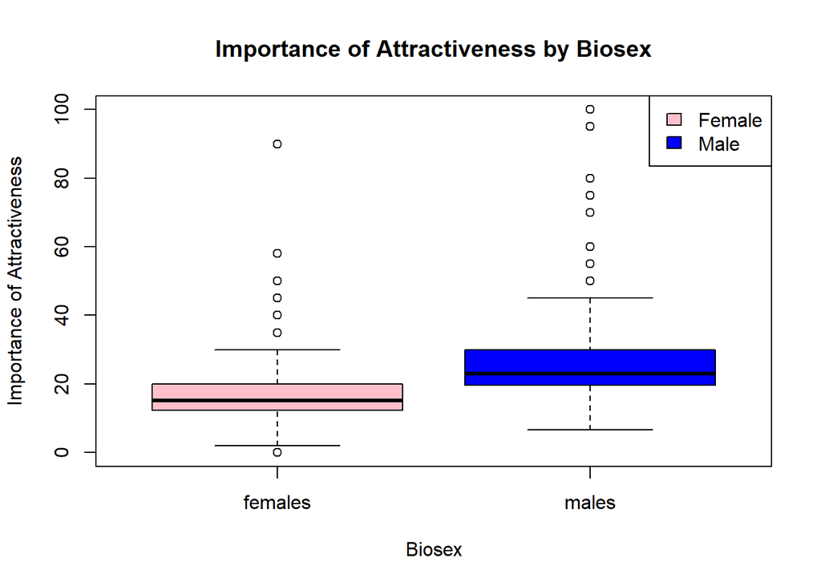

```r
boxplot(Importance ~ Biosex, data = dating,
        main = "Importance of Attractiveness by Biosex",
        xlab = "Biosex", ylab = "Importance of Attractiveness",
        col = c("pink", "blue"))


legend("topright", legend = c("Female", "Male"), fill = c("pink", "blue"))
```

What do you observe?  
**It appears that males have a slightly higher level of importance when it comes to attractiveness**

Create a table of summary statistics for each group (`favstats()`):

```r
favstats(Importance ~ Biosex, data = dating)
```

```
   Biosex  min    Q1 median Q3 max     mean        sd   n missing
1 females 0.00 12.24  15.09 20  90 18.02037  9.929864 269       0
2   males 6.67 19.57  23.00 30 100 27.24880 13.955701 275       0
```

## Perform the Appropriate Analysis

### Hypothesis Test

State your null and alternative hypotheses:

$$H_0: \mu_{male} = \mu_{female}$$

$$H_a: \mu_{male} > \mu_{female}$$

**NOTE**: The default for R is to set group order alphabetically. This means Group 1 = Female.

Compare the importance of attractiveness for males and females.

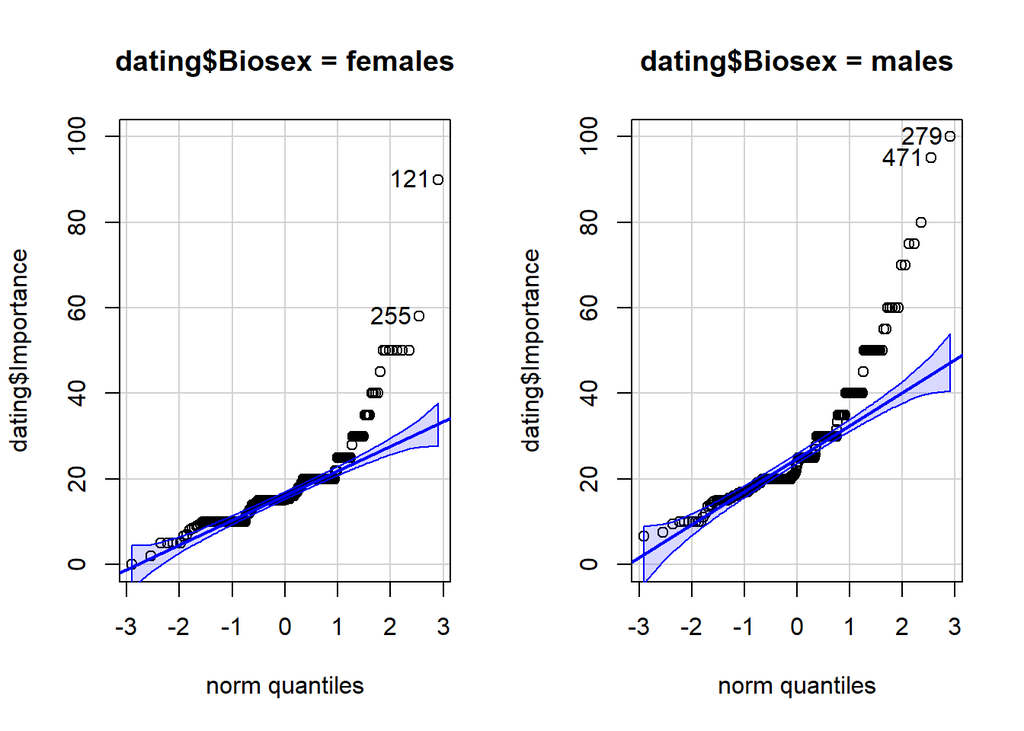

```r
qqPlot(dating$Importance, groups = dating$Biosex)
```

Why is it OK to continue with the analysis?  
**The sample sizes are above 30 and the samples are random.**

Perform a t-test.

```r
t_test <- t.test(dating$Importance ~ dating$Biosex, alternative = "less")
t_test
```

```
    Welch Two Sample t-test

data:  dating$Importance by dating$Biosex
t = -8.9016, df = 495.36, p-value < 2.2e-16
alternative hypothesis: true difference in means between group females and group males is less than 0
95 percent confidence interval:
      -Inf -7.519991
sample estimates:
mean in group females   mean in group males
             18.02037              27.24880
```

What is the value of the test statistic?  
**t = -8.9016**

How many degrees of freedom for this test?  
**df = 495.36**

What is the p-value?  
**p-value < 2.2e-16**

What do you conclude?  
**Since the p-value is significantly smaller than 0.05, we reject the null hypothesis. This means we have strong evidence suggesting that males report valuing attractiveness more than females.**

### Confidence Interval

Create a confidence interval for the difference of the average Importance Score between both groups:

```r
t.test(dating$Importance ~ dating$Biosex, conf.level = .99)$conf.int
```

```
[1] -11.909152  -6.547704
attr(,"conf.level")
[1] 0.99
```

# Keeping Balance

## Introduction

How difficult is it to maintain your balance while concentrating? Is it more difficult when you are older? Nine elderly people (6 men and 3 women) and eight young men were subjects in an experiment. Each subject stood barefoot on a “force platform” and was asked to maintain a stable upright position and to react as quickly as possible to an unpredictable noise by pressing a hand-held button. The noise came randomly, and the subject concentrated on reacting as quickly as possible. The platform automatically measured how much each subject swayed in millimetres in both the forward/backward and the side-to-side directions.

The data file side_sway gives the sway observed in the side-to-side direction. Determine if the amount of swaying side-to-side is greater for elderly people than younger people using a level of significance of 0.05. Let the elderly people be group 1 and the younger people be group 2.

## Load the Data

```r
side_sway <- import('https://github.com/byuistats/Math221D_Cannon/raw/master/Data/side_sway_long.csv')
```

## Explore the Data

Create a side-by-side boxplot for the amount of side sway for each age group:

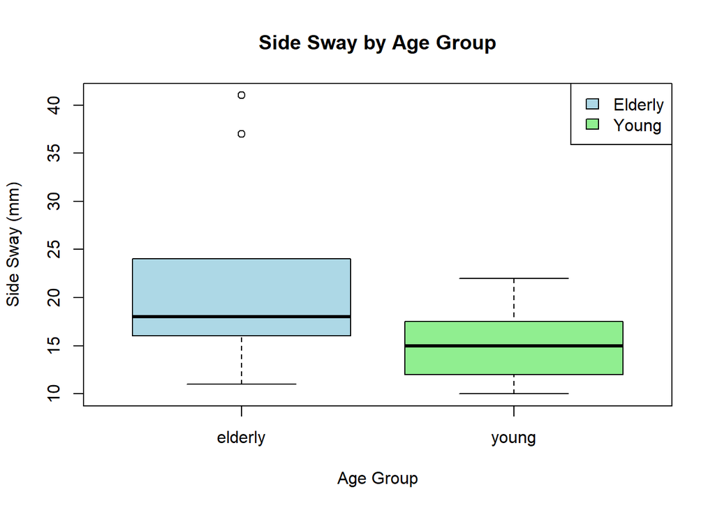

```r
boxplot(Sidesway ~ Age_Group, data = side_sway,
        main = "Side Sway by Age Group",
        xlab = "Age Group", ylab = "Side Sway (mm)",
        col = c("lightblue", "lightgreen"))

legend("topright", legend = c("Elderly", "Young"), fill = c("lightblue", "lightgreen"))
```

What do you observe?  
**Elderly people appear to have a higher median side sway.**

Create a table of summary statistics for each group (`favstats()`):

```r
favstats(Sidesway ~ Age_Group, data = side_sway)
```

```
  Age_Group min Q1 median    Q3 max     mean        sd n missing
1   elderly  11 16     18 24.00  41 22.22222 10.268615 9       0
2     young  10 12     15 17.25  22 15.12500  3.907411 8       0
```

## Perform the Appropriate Analysis

### Hypothesis Test

State your null and alternative hypotheses:

$$H_0: \mu_{elderly} = \mu_{young}$$

$$H_a: \mu_{elderly} > \mu_{young}$$

Perform the appropriate t-test:

```r
t_test <- t.test(side_sway$Sidesway ~ side_sway$Age_Group, alternative = "greater")
t_test
```

```
    Welch Two Sample t-test

data:  side_sway$Sidesway by side_sway$Age_Group
t = 1.9228, df = 10.5, p-value = 0.04102
alternative hypothesis: true difference in means between group elderly and group young is greater than 0
95 percent confidence interval:
 0.4393617       Inf
sample estimates:
mean in group elderly   mean in group young
             22.22222              15.12500
```

What is the value of the sample test statistic?  
**t = 1.9228**

How many degrees of freedom does the test statistic have?  
**df = 10.5**

What is the P-value?  
**p-value = 0.04102**

Can we trust the P-value? (Central Limit Theorem (n>30)? Normality of differences?)

1. How many data points in each group?  
   **elderly = 9**  
   **young = 8**
2. Check normality of the side sway measurements for each group

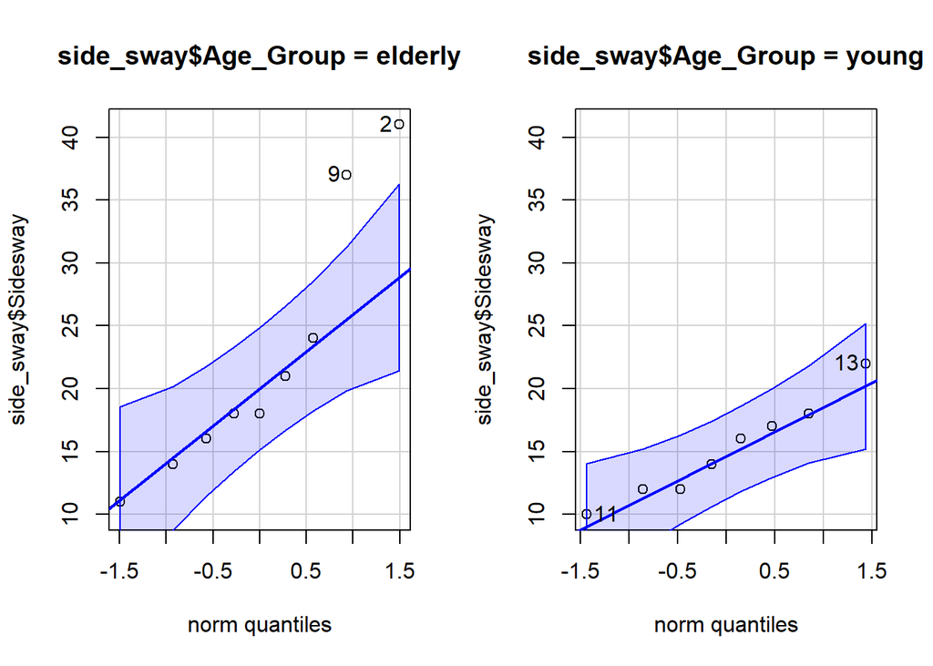

```r
qqPlot(side_sway$Sidesway, groups = side_sway$Age_Group)
```

### Confidence Interval

Create a 95% confidence interval for the difference of the average side sway for elderly and young people.

```r
conf_int <- t_test$conf.int
conf_int
```

```
[1] 0.4393617       Inf
attr(,"conf.level")
[1] 0.95
```

What is the upper and lower bound of the confidence interval?  
**Lower Bound: 0.4393617**  
**Upper Bound: Infinity**

Give an explanation of the confidence interval in context of the problem:  
**Given that the entire confidence interval is positive and does not include zero, we can conclude that there is a statistically significant difference between the two groups. Elderly people exhibit greater side sway than younger people when reacting to an unpredictable noise while maintaining balance.**